# HW2

**NYC Restaurants**

Setup

```python
cd C:\Users\ayuan\OneDrive\Documents\2. UT Summer\2.MIS Data Analytics Programming\Assignments
```

```python
from pandas import Series, DataFrame
import pandas as pd
%pylab inline
df = pd.read_csv('NYC_Restaurants.csv', dtype=unicode)
```

[Q1, 6 points] Create a unique name for each restaurant.

```python
df['RESTAURANT']=df['DBA']+' '+df['BUILDING']+' '+df['STREET']+' '+df['ZIPCODE']
df['RESTAURANT'][:10]
```

```
0                    WENDY'S 469 FLATBUSH AVENUE 11225
1                    WENDY'S 469 FLATBUSH AVENUE 11225
2                    WENDY'S 469 FLATBUSH AVENUE 11225
3                    WENDY'S 469 FLATBUSH AVENUE 11225
4                    WENDY'S 469 FLATBUSH AVENUE 11225
5               TOV KOSHER KITCHEN 97-22 63 ROAD 11374
6               TOV KOSHER KITCHEN 97-22 63 ROAD 11374
7               TOV KOSHER KITCHEN 97-22 63 ROAD 11374
8               TOV KOSHER KITCHEN 97-22 63 ROAD 11374
9    BRUNOS ON THE BOULEVARD 8825 ASTORIA BOULEVARD...
Name: RESTAURANT, dtype: object
```

[Q2, 6 points] How many restaurants are included in the data?

```python
df_dedup = df.drop_duplicates(subset='RESTAURANT')
print len(df_dedup),'restaurants are included in the data.'
```

```
10114 restaurants are included in the data.
```

[Q3, 6 points] How many chains are there?

```python
restaurant_count=df_dedup['DBA'].value_counts()
restaurant_count
chains_count=restaurant_count[(restaurant_count.values>=2)]
chains_count
print len(chains_count),'chains are included in the data.'
```

```
368 chains are included in the data.
```

[Q4, 6 points] Plot a bar graph of the top 20 most popular chains.

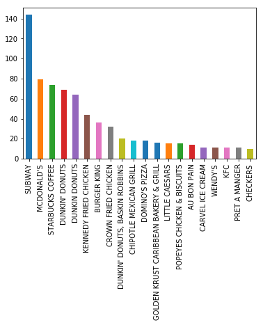

```python
top_20_chains = chains_count[:20]
top_20_chains.plot(kind='bar')
```

[Q5, 6 points] What fraction of all restaurants are chains?

```python
chains_sum=chains_count.sum()
chains_fraction=1.0*chains_sum/len(df_dedup)
print chains_fraction*100,'% of all restaurants are chains.'
```

```
16.47221672928614 % of all restaurants are chains.
```

[Q6, 6 points] Plot the number of non-chain restaurants in each boro.

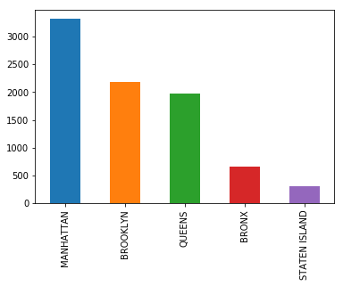

```python
non_chains_count=restaurant_count[(restaurant_count.values<2)]
non_chains_count
def is_chain(x):
    return (x in non_chains_count.index)
mask_non_chains = df_dedup['DBA'].map(is_chain)
df_non_chains=df_dedup[mask_non_chains]
mask_missing= (df_non_chains['BORO'] == 'Missing')
df_non_chains.loc[mask_missing,'BORO'] = np.nan
df_non_chains['BORO'].value_counts().plot(kind='bar')
```

[Q7, 8 points] Plot the fraction of non-chain restaurants in each boro.

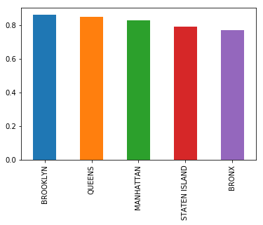

```python
mask_missing_= (df_dedup['BORO'] == 'Missing')
df_dedup.loc[mask_missing_,'BORO'] = np.nan
res_per_boro=df_dedup['BORO'].value_counts()
nonchains_per_boro=df_non_chains['BORO'].value_counts()
nonchains_frac=1.0*nonchains_per_boro/res_per_boro
nonchains_frac_rank=nonchains_frac.sort_values(ascending=False)
nonchains_frac_rank.plot(kind='bar')
#Is the boro with the most independent restaurants also the one with the highest ratio of independent restaurants?
#No. Manhattan has the most independent restaurants, but Brooklyn has the highest ratio of independent restaurants.
```

[Q8, 6 points] Plot the popularity of cuisines.

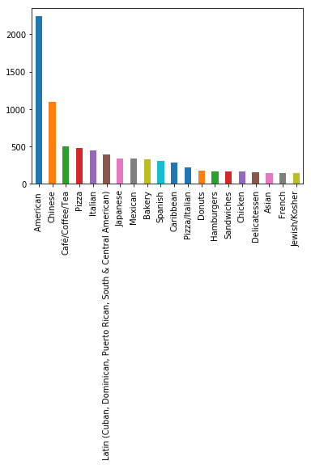

```python
cuisine_count=df_dedup['CUISINE DESCRIPTION'].value_counts()
cuisine_count[:20].plot(kind='bar')
```

[Q9, 9 points] Plot the cuisines among restaurants which never got cited for violations.

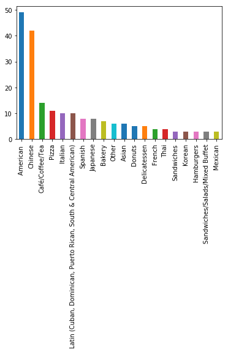

```python
mask_violation=(df['VIOLATION CODE'].isnull()==False)
df_vio=df[mask_violation]
rest_vio=list(df_vio['RESTAURANT'])
df_nonvio=df_dedup[~df_dedup.RESTAURANT.isin(rest_vio)]
nonvio_cuisine_count=df_nonvio['CUISINE DESCRIPTION'].value_counts()
nonvio_cuisine_count[:20].plot(kind='bar')
```

[Q10, 6 points] What cuisines tend to be the \cleanest"?

```python
mask_clean=(cuisine_count.values>=20)
over20_cuisine_count=cuisine_count[mask_clean]
cuisine_clean_ratio=(1.0*nonvio_cuisine_count/over20_cuisine_count).dropna()
cuisine_clean_ratio=cuisine_clean_ratio.sort_values(ascending=False)
cuisine_clean_ratio[:10]
```

```
Soul Food                        0.090909
Vietnamese/Cambodian/Malaysia    0.062500
Other                            0.058252
Soups & Sandwiches               0.047619
Continental                      0.047619
Barbecue                         0.047619
Asian                            0.041096
Chinese                          0.038251
Greek                            0.036364
Peruvian                         0.035714
Name: CUISINE DESCRIPTION, dtype: float64
```

[Q11, 8 points] What are the most common violations in each borough?

```python
mask_missing__= (df['BORO'] == 'Missing')
df.loc[mask_missing__,'BORO'] = np.nan
violation_boro= pd.crosstab(df['VIOLATION DESCRIPTION'], df['BORO'])
violation_boro.idxmax()
```

```
BORO
BRONX            Non-food contact surface improperly constructe...
BROOKLYN         Non-food contact surface improperly constructe...
MANHATTAN        Non-food contact surface improperly constructe...
QUEENS           Non-food contact surface improperly constructe...
STATEN ISLAND    Non-food contact surface improperly constructe...
dtype: object
```

[Q12, 9 points] What are the most common violations per borough, after normalizing for the relative abundance of each violation?

```python
violationFrequency=df['VIOLATION DESCRIPTION'].value_counts()
vio_normalize=1.0*violation_boro.T/violationFrequency
vio_normalize.T.idxmax()
```

```
BORO
BRONX                                  Unprotected food re-served.
BROOKLYN         Precooked potentially hazardous food from comm...
MANHATTAN        Out-of package sale of tobacco products observed.
QUEENS           Caloric content range (minimum to maximum) not...
STATEN ISLAND    Eggs found dirty/cracked; liquid, frozen or po...
dtype: object
```

[Q13, 8 points] How many phone area codes correspond to a single zipcode?

```python
df['AREACODE']=df['PHONE'].str[:3]
df_dedup['AREACODE']=df_dedup['PHONE'].str[:3]
df_areacode_zip=df[['AREACODE','ZIPCODE']]
df_areacode_zip=df_areacode_zip.drop_duplicates(subset=['AREACODE','ZIPCODE'])
areacode_zip_count=df_areacode_zip['AREACODE'].value_counts()
mask_areacode=(areacode_zip_count==1)
ac_zip_single=areacode_zip_count[mask_areacode]
print len(ac_zip_single),'phone area codes correspond to a single zipcode.'
```

```
34 phone area codes correspond to a single zipcode.
```

[Q14, 10 points] Find common misspellings of street names

```python
#STREET TYPE
street_split=df_dedup['STREET'].str.split()
street_split_dict=dict(street_split)
street_type_dict={}
for i in street_split_dict:
    street_type_dict[i]=street_split_dict[i][-1]
street_type=pd.Series(street_type_dict)
df_dedup['STREET TYPE']=street_type
df_dedup['STREET TYPE']
```

```
0           AVENUE
5             ROAD
9        BOULEVARD
16          AVENUE
22         HIGHWAY
24          AVENUE
26          AVENUE
30          STREET
31            WEST
34        BROADWAY
41          AVENUE
42          STREET
44          AVENUE
49             AVE
53       BOULEVARD
```

[output cut: 47 more lines]

```python
#STREET BASE
street_base_dict={}
for m in street_split_dict:
    if len(street_split_dict[m][:-1])>0:
        street_base_dict[m]=street_split_dict[m][:-1]
        street_base_dict[m]=''.join(street_base_dict[m])
street_base=pd.Series(street_base_dict)
df_dedup['STREET BASE']=street_base.dropna()
df_dedup['STREET BASE']
```

```
0                 FLATBUSH
5                       63
9                  ASTORIA
16                  SUTTER
22                   KINGS
24                  CHURCH
26                       3
30                  EAST74
31            PROSPECTPARK
34                     NaN
41                COLUMBUS
42                   COURT
44                       5
49             238SPOFFORD
53                 VICTORY
```

[output cut: 47 more lines]

```python
#STREET BASE & ZIP
df_dedup['STREET BASE & ZIP']=df_dedup['STREET BASE']+' '+df_dedup['ZIPCODE']
df_dedup['STREET BASE & ZIP'].dropna()
```

```
0                 FLATBUSH 11225
5                       63 11374
9                  ASTORIA 11369
16                  SUTTER 11208
22                   KINGS 11223
24                  CHURCH 11218
26                       3 11209
30                  EAST74 10021
31            PROSPECTPARK 11215
41                COLUMBUS 10025
42                   COURT 11201
44                       5 11209
49             238SPOFFORD 10474
53                 VICTORY 10314
57            METROPOLITAN 11379
```

[output cut: 47 more lines]

```python
#Create a table
table=DataFrame([df_dedup['STREET TYPE'],df_dedup['STREET BASE'],df_dedup['STREET BASE & ZIP']])
st_table=table.T
st_table=st_table.drop_duplicates(subset=['STREET TYPE','STREET BASE','STREET BASE & ZIP'])
st_table1=st_table.dropna()
st_table1
```

|  | STREET TYPE | STREET BASE | STREET BASE & ZIP |
| --- | --- | --- | --- |
| 0 | AVENUE | FLATBUSH | FLATBUSH 11225 |
| 5 | ROAD | 63 | 63 11374 |
| 9 | BOULEVARD | ASTORIA | ASTORIA 11369 |
| 16 | AVENUE | SUTTER | SUTTER 11208 |
| 22 | HIGHWAY | KINGS | KINGS 11223 |
| 24 | AVENUE | CHURCH | CHURCH 11218 |
| 26 | AVENUE | 3 | 3 11209 |
| 30 | STREET | EAST74 | EAST74 10021 |
| 31 | WEST | PROSPECTPARK | PROSPECTPARK 11215 |
| 41 | AVENUE | COLUMBUS | COLUMBUS 10025 |
| 42 | STREET | COURT | COURT 11201 |
| 44 | AVENUE | 5 | 5 11209 |
| 49 | AVE | 238SPOFFORD | 238SPOFFORD 10474 |
| 53 | BOULEVARD | VICTORY | VICTORY 10314 |
| 57 | AVENUE | METROPOLITAN | METROPOLITAN 11379 |
| 58 | STREET | WEST72 | WEST72 10023 |
| 61 | J | AVENUE | AVENUE 11230 |
| 65 | PLAZA | NEWDORP | NEWDORP 10306 |
| 68 | LANE | GIFFORDS | GIFFORDS 10308 |
| 73 | STREET | FULTON | FULTON 10038 |
| 77 | STREET | WEST52 | WEST52 10019 |
| 81 | SOUTH | CENTRALPARK | CENTRALPARK 10019 |
| 84 | STREET | WEST51 | WEST51 10019 |
| 86 | EXTENSION | FLATBUSHAVENUE | FLATBUSHAVENUE 11201 |
| 89 | STREET | EAST31 | EAST31 10016 |
| 95 | ST | EAST77 | EAST77 10021 |
| 99 | STREET | 37 | 37 11232 |
| 102 | AVENUE | HAVILAND | HAVILAND 10462 |
| 104 | COURT | BOUCK | BOUCK 11223 |
| 105 | STREET | BAXTER | BAXTER 10013 |
| ... | ... | ... | ... |
| 44336 | AVE | 20TH | 20TH 11214 |
| 44346 | ST | E44TH | E44TH 10017 |
| 44358 | ST | FRANKLIN | FRANKLIN 10013 |
| 44362 | AVE | MADISON | MADISON 10010 |
| 44364 | ST | 38TH | 38TH 11218 |
| 44387 | AVE | 5TH | 5TH 10018 |
| 44401 | AVE | FRANKLIN | FRANKLIN 11238 |
| 44410 | ST | W8TH | W8TH 10011 |
| 44418 | AVE | DRIGGS | DRIGGS 11222 |
| 44431 | AVE | KINGSLAND | KINGSLAND 11211 |
| 44447 | ST | BEACH116TH | BEACH116TH 11694 |
| 44450 | BLVD | SUTPHIN | SUTPHIN 11434 |
| 44455 | ST | E174TH | E174TH 10460 |
| 44464 | ST | PEARL | PEARL 11201 |
| 44466 | ST | HUDSON | HUDSON 10013 |
| 44486 | SW | PROSPECTPARK | PROSPECTPARK 11218 |
| 44487 | ST | LIVINGSTON | LIVINGSTON 11201 |
| 44519 | ST | W12TH | W12TH 10011 |
| 44528 | BLVD | FREDERICKDOUGLASS | FREDERICKDOUGLASS 10030 |
| 44549 | ST | CANAL | CANAL 10013 |
| 44552 | AVE | LAFAYETTE | LAFAYETTE 10301 |
| 44557 | AVE | GREENE | GREENE 11216 |
| 44584 | AVE | FLATLANDS | FLATLANDS 11234 |
| 44587 | AVE | BEDFORD | BEDFORD 11249 |
| 44593 | ST | NORFOLK | NORFOLK 10002 |
| 44613 | ST | 9TH | 9TH 11101 |
| 44617 | AVE | ROGERS | ROGERS 11216 |
| 44618 | AVE | GRAND | GRAND 11378 |
| 44619 | ST | E48TH | E48TH 10017 |
| 44629 | ST | E13TH | E13TH 10009 |

2760 rows × 3 columns

```python
#Merge the table
st_table_square= st_table1.merge(st_table1,
                                   left_on=['STREET BASE & ZIP','STREET BASE'],
                                   right_on=['STREET BASE & ZIP','STREET BASE'],
                                   suffixes=['_1', '_2'])
st_table_square
```

|  | STREET TYPE_1 | STREET BASE | STREET BASE & ZIP | STREET TYPE_2 |
| --- | --- | --- | --- | --- |
| 0 | AVENUE | FLATBUSH | FLATBUSH 11225 | AVENUE |
| 1 | AVENUE | FLATBUSH | FLATBUSH 11225 | AVE |
| 2 | AVE | FLATBUSH | FLATBUSH 11225 | AVENUE |
| 3 | AVE | FLATBUSH | FLATBUSH 11225 | AVE |
| 4 | ROAD | 63 | 63 11374 | ROAD |
| 5 | ROAD | 63 | 63 11374 | DRIVE |
| 6 | DRIVE | 63 | 63 11374 | ROAD |
| 7 | DRIVE | 63 | 63 11374 | DRIVE |
| 8 | BOULEVARD | ASTORIA | ASTORIA 11369 | BOULEVARD |
| 9 | AVENUE | SUTTER | SUTTER 11208 | AVENUE |
| 10 | HIGHWAY | KINGS | KINGS 11223 | HIGHWAY |
| 11 | AVENUE | CHURCH | CHURCH 11218 | AVENUE |
| 12 | AVENUE | CHURCH | CHURCH 11218 | AVE |
| 13 | AVE | CHURCH | CHURCH 11218 | AVENUE |
| 14 | AVE | CHURCH | CHURCH 11218 | AVE |
| 15 | AVENUE | 3 | 3 11209 | AVENUE |
| 16 | STREET | EAST74 | EAST74 10021 | STREET |
| 17 | WEST | PROSPECTPARK | PROSPECTPARK 11215 | WEST |
| 18 | WEST | PROSPECTPARK | PROSPECTPARK 11215 | W |
| 19 | W | PROSPECTPARK | PROSPECTPARK 11215 | WEST |
| 20 | W | PROSPECTPARK | PROSPECTPARK 11215 | W |
| 21 | AVENUE | COLUMBUS | COLUMBUS 10025 | AVENUE |
| 22 | AVENUE | COLUMBUS | COLUMBUS 10025 | AVE |
| 23 | AVE | COLUMBUS | COLUMBUS 10025 | AVENUE |
| 24 | AVE | COLUMBUS | COLUMBUS 10025 | AVE |
| 25 | STREET | COURT | COURT 11201 | STREET |
| 26 | STREET | COURT | COURT 11201 | ST |
| 27 | ST | COURT | COURT 11201 | STREET |
| 28 | ST | COURT | COURT 11201 | ST |
| 29 | AVENUE | 5 | 5 11209 | AVENUE |
| ... | ... | ... | ... | ... |
| 3612 | ST | E40TH | E40TH 10016 | ST |
| 3613 | ST | E35TH | E35TH 10016 | ST |
| 3614 | ST | W59TH | W59TH 10019 | ST |
| 3615 | ST | E172ND | E172ND 10472 | ST |
| 3616 | AVE | ETREMONT | ETREMONT 10465 | AVE |
| 3617 | AVE | 1ST | 1ST 10003 | AVE |
| 3618 | AVE | 1ST | 1ST 10016 | AVE |
| 3619 | AVE | TWOMBLY | TWOMBLY 10306 | AVE |
| 3620 | ST | S5TH | S5TH 11211 | ST |
| 3621 | ST | E50TH | E50TH 10022 | ST |
| 3622 | BLVD | SPRINGFIELD | SPRINGFIELD 11427 | BLVD |
| 3623 | ST | E187TH | E187TH 10458 | ST |
| 3624 | AVE | BELMONT | BELMONT 11208 | AVE |
| 3625 | AVE | 1ST | 1ST 10009 | AVE |
| 3626 | AVE | 20TH | 20TH 11214 | AVE |
| 3627 | ST | E44TH | E44TH 10017 | ST |
| 3628 | ST | 38TH | 38TH 11218 | ST |
| 3629 | AVE | 5TH | 5TH 10018 | AVE |
| 3630 | ST | W8TH | W8TH 10011 | ST |
| 3631 | AVE | KINGSLAND | KINGSLAND 11211 | AVE |
| 3632 | ST | BEACH116TH | BEACH116TH 11694 | ST |
| 3633 | ST | E174TH | E174TH 10460 | ST |
| 3634 | ST | PEARL | PEARL 11201 | ST |
| 3635 | ST | W12TH | W12TH 10011 | ST |
| 3636 | AVE | LAFAYETTE | LAFAYETTE 10301 | AVE |
| 3637 | AVE | GREENE | GREENE 11216 | AVE |
| 3638 | ST | 9TH | 9TH 11101 | ST |
| 3639 | AVE | ROGERS | ROGERS 11216 | AVE |
| 3640 | ST | E48TH | E48TH 10017 | ST |
| 3641 | ST | E13TH | E13TH 10009 | ST |

3642 rows × 4 columns

```python
#Different st.type
st_table_dif=st_table_square.loc[(st_table_square['STREET TYPE_1']!=st_table_square['STREET TYPE_2'])]
st_table_dif
```

|  | STREET TYPE_1 | STREET BASE | STREET BASE & ZIP | STREET TYPE_2 |
| --- | --- | --- | --- | --- |
| 1 | AVENUE | FLATBUSH | FLATBUSH 11225 | AVE |
| 2 | AVE | FLATBUSH | FLATBUSH 11225 | AVENUE |
| 5 | ROAD | 63 | 63 11374 | DRIVE |
| 6 | DRIVE | 63 | 63 11374 | ROAD |
| 12 | AVENUE | CHURCH | CHURCH 11218 | AVE |
| 13 | AVE | CHURCH | CHURCH 11218 | AVENUE |
| 18 | WEST | PROSPECTPARK | PROSPECTPARK 11215 | W |
| 19 | W | PROSPECTPARK | PROSPECTPARK 11215 | WEST |
| 22 | AVENUE | COLUMBUS | COLUMBUS 10025 | AVE |
| 23 | AVE | COLUMBUS | COLUMBUS 10025 | AVENUE |
| 26 | STREET | COURT | COURT 11201 | ST |
| 27 | ST | COURT | COURT 11201 | STREET |
| 32 | BOULEVARD | VICTORY | VICTORY 10314 | BLVD |
| 33 | BLVD | VICTORY | VICTORY 10314 | BOULEVARD |
| 38 | J | AVENUE | AVENUE 11230 | M |
| 39 | J | AVENUE | AVENUE 11230 | H |
| 40 | M | AVENUE | AVENUE 11230 | J |
| 42 | M | AVENUE | AVENUE 11230 | H |
| 43 | H | AVENUE | AVENUE 11230 | J |
| 44 | H | AVENUE | AVENUE 11230 | M |
| 47 | PLAZA | NEWDORP | NEWDORP 10306 | LANE |
| 48 | LANE | NEWDORP | NEWDORP 10306 | PLAZA |
| 64 | AVENUE | NOSTRAND | NOSTRAND 11226 | AVE |
| 65 | AVE | NOSTRAND | NOSTRAND 11226 | AVENUE |
| 73 | TURNPIKE | UNION | UNION 11366 | TPKE |
| 74 | TPKE | UNION | UNION 11366 | TURNPIKE |
| 84 | AVENUE | PORTRICHMOND | PORTRICHMOND 10302 | AVE |
| 85 | AVE | PORTRICHMOND | PORTRICHMOND 10302 | AVENUE |
| 89 | BOULEVARD | JUNCTION | JUNCTION 11368 | BLVD |
| 90 | BLVD | JUNCTION | JUNCTION 11368 | BOULEVARD |
| ... | ... | ... | ... | ... |
| 3130 | AVENUE | RALPH | RALPH 11221 | AVE |
| 3131 | AVE | RALPH | RALPH 11221 | AVENUE |
| 3164 | STREET | GANSEVOORT | GANSEVOORT 10014 | ST |
| 3165 | STREET | GANSEVOORT | GANSEVOORT 10014 | MARKET |
| 3166 | ST | GANSEVOORT | GANSEVOORT 10014 | STREET |
| 3168 | ST | GANSEVOORT | GANSEVOORT 10014 | MARKET |
| 3169 | MARKET | GANSEVOORT | GANSEVOORT 10014 | STREET |
| 3170 | MARKET | GANSEVOORT | GANSEVOORT 10014 | ST |
| 3174 | AVENUE | 37TH | 37TH 11372 | AVE |
| 3175 | AVE | 37TH | 37TH 11372 | AVENUE |
| 3183 | STREET | COLUMBIA | COLUMBIA 11201 | PL |
| 3184 | PL | COLUMBIA | COLUMBIA 11201 | STREET |
| 3190 | STREET | LAWRENCE | LAWRENCE 11201 | ST |
| 3191 | ST | LAWRENCE | LAWRENCE 11201 | STREET |
| 3199 | AVENUE | OCEAN | OCEAN 11229 | AVE |
| 3200 | AVE | OCEAN | OCEAN 11229 | AVENUE |
| 3205 | AVENUE | 7TH | 7TH 11220 | AVE |
| 3206 | AVE | 7TH | 7TH 11220 | AVENUE |
| 3210 | STREET | W43RD | W43RD 10036 | ST |
| 3211 | ST | W43RD | W43RD 10036 | STREET |
| 3233 | STREET | BLEECKER | BLEECKER 11237 | ST |
| 3234 | ST | BLEECKER | BLEECKER 11237 | STREET |
| 3240 | SOUTHWEST | PROSPECTPARK | PROSPECTPARK 11218 | SW |
| 3241 | SW | PROSPECTPARK | PROSPECTPARK 11218 | SOUTHWEST |
| 3274 | AVE | PATCHEN | PATCHEN 11233 | AVENUE |
| 3275 | AVENUE | PATCHEN | PATCHEN 11233 | AVE |
| 3360 | STREET | 48 | 48 11101 | AVENUE |
| 3361 | AVENUE | 48 | 48 11101 | STREET |
| 3411 | PARKWAY | HUTCHINSONRIVER | HUTCHINSONRIVER 10465 | PKWY |
| 3412 | PKWY | HUTCHINSONRIVER | HUTCHINSONRIVER 10465 | PARKWAY |

882 rows × 4 columns

```python
#Cross-tabulation
st_cross=pd.crosstab(st_table_dif['STREET TYPE_1'], st_table_dif['STREET TYPE_2'])
st_cross
```

| STREET TYPE_2 STREET TYPE_1 | A | AAVENUE | AIRPOR | AIRPORT | AVE | AVENUE | AVEUE | B | BLVD | BOULEARD | ... | SW | TERMINAL | TPKE | TURNPIKE | U | V | W | WEST | X | Z |
| --- | --- | --- | --- | --- | --- | --- | --- | --- | --- | --- | --- | --- | --- | --- | --- | --- | --- | --- | --- | --- | --- |
| A | 0 | 0 | 0 | 0 | 0 | 0 | 0 | 2 | 0 | 0 | ... | 0 | 0 | 0 | 0 | 0 | 0 | 0 | 0 | 0 | 0 |
| AAVENUE | 0 | 0 | 0 | 0 | 1 | 1 | 0 | 0 | 0 | 0 | ... | 0 | 0 | 0 | 0 | 0 | 0 | 0 | 0 | 0 | 0 |
| AIRPOR | 0 | 0 | 0 | 1 | 0 | 0 | 0 | 0 | 0 | 0 | ... | 0 | 0 | 0 | 0 | 0 | 0 | 0 | 0 | 0 | 0 |
| AIRPORT | 0 | 0 | 1 | 0 | 0 | 0 | 0 | 0 | 0 | 0 | ... | 0 | 0 | 0 | 0 | 0 | 0 | 0 | 0 | 0 | 0 |
| AVE | 0 | 1 | 0 | 0 | 0 | 163 | 0 | 0 | 0 | 0 | ... | 0 | 0 | 0 | 0 | 0 | 0 | 0 | 0 | 0 | 0 |
| AVENUE | 0 | 1 | 0 | 0 | 163 | 0 | 1 | 0 | 0 | 0 | ... | 0 | 0 | 0 | 0 | 0 | 0 | 0 | 0 | 0 | 0 |
| AVEUE | 0 | 0 | 0 | 0 | 0 | 1 | 0 | 0 | 0 | 0 | ... | 0 | 0 | 0 | 0 | 0 | 0 | 0 | 0 | 0 | 0 |
| B | 2 | 0 | 0 | 0 | 0 | 0 | 0 | 0 | 0 | 0 | ... | 0 | 0 | 0 | 0 | 0 | 0 | 0 | 0 | 0 | 0 |
| BLVD | 0 | 0 | 0 | 0 | 0 | 0 | 0 | 0 | 0 | 1 | ... | 0 | 0 | 0 | 0 | 0 | 0 | 0 | 0 | 0 | 0 |
| BOULEARD | 0 | 0 | 0 | 0 | 0 | 0 | 0 | 0 | 1 | 0 | ... | 0 | 0 | 0 | 0 | 0 | 0 | 0 | 0 | 0 | 0 |
| BOULEVARD | 0 | 0 | 0 | 0 | 0 | 0 | 0 | 0 | 49 | 1 | ... | 0 | 0 | 0 | 0 | 0 | 0 | 0 | 0 | 0 | 0 |
| BULEVARD | 0 | 0 | 0 | 0 | 0 | 0 | 0 | 0 | 1 | 0 | ... | 0 | 0 | 0 | 0 | 0 | 0 | 0 | 0 | 0 | 0 |
| C | 1 | 0 | 0 | 0 | 0 | 0 | 0 | 1 | 0 | 0 | ... | 0 | 0 | 0 | 0 | 0 | 0 | 0 | 0 | 0 | 0 |
| CENTER | 0 | 0 | 0 | 0 | 0 | 0 | 0 | 0 | 0 | 0 | ... | 0 | 0 | 0 | 0 | 0 | 0 | 0 | 0 | 0 | 0 |
| CTR | 0 | 0 | 0 | 0 | 0 | 0 | 0 | 0 | 0 | 0 | ... | 0 | 0 | 0 | 0 | 0 | 0 | 0 | 0 | 0 | 0 |
| D | 1 | 0 | 0 | 0 | 0 | 0 | 0 | 1 | 0 | 0 | ... | 0 | 0 | 0 | 0 | 0 | 0 | 0 | 0 | 0 | 0 |
| DR | 0 | 0 | 0 | 0 | 0 | 0 | 0 | 0 | 0 | 0 | ... | 0 | 0 | 0 | 0 | 0 | 0 | 0 | 0 | 0 | 0 |
| DRIVE | 0 | 0 | 0 | 0 | 0 | 0 | 0 | 0 | 0 | 0 | ... | 0 | 0 | 0 | 0 | 0 | 0 | 0 | 0 | 0 | 0 |
| EAST | 0 | 0 | 0 | 0 | 0 | 0 | 0 | 0 | 0 | 0 | ... | 0 | 0 | 0 | 0 | 0 | 0 | 0 | 1 | 0 | 0 |
| EXPRESS | 0 | 0 | 0 | 0 | 0 | 0 | 0 | 0 | 0 | 0 | ... | 0 | 0 | 0 | 0 | 0 | 0 | 0 | 0 | 0 | 0 |
| EXPRESSWAY | 0 | 0 | 0 | 0 | 0 | 0 | 0 | 0 | 0 | 0 | ... | 0 | 0 | 0 | 0 | 0 | 0 | 0 | 0 | 0 | 0 |
| EXPY | 0 | 0 | 0 | 0 | 0 | 0 | 0 | 0 | 0 | 0 | ... | 0 | 0 | 0 | 0 | 0 | 0 | 0 | 0 | 0 | 0 |
| H | 0 | 0 | 0 | 0 | 0 | 0 | 0 | 0 | 0 | 0 | ... | 0 | 0 | 0 | 0 | 1 | 0 | 0 | 0 | 0 | 0 |
| HIGHWAY | 0 | 0 | 0 | 0 | 0 | 0 | 0 | 0 | 0 | 0 | ... | 0 | 0 | 0 | 0 | 0 | 0 | 0 | 0 | 0 | 0 |
| HWY | 0 | 0 | 0 | 0 | 0 | 0 | 0 | 0 | 0 | 0 | ... | 0 | 0 | 0 | 0 | 0 | 0 | 0 | 0 | 0 | 0 |
| I | 0 | 0 | 0 | 0 | 0 | 0 | 0 | 0 | 0 | 0 | ... | 0 | 0 | 0 | 0 | 0 | 0 | 0 | 0 | 0 | 0 |
| INTEL | 0 | 0 | 0 | 1 | 0 | 0 | 0 | 0 | 0 | 0 | ... | 0 | 0 | 0 | 0 | 0 | 0 | 0 | 0 | 0 | 0 |
| J | 0 | 0 | 0 | 0 | 0 | 0 | 0 | 0 | 0 | 0 | ... | 0 | 0 | 0 | 0 | 0 | 0 | 0 | 0 | 0 | 0 |
| K | 0 | 0 | 0 | 0 | 0 | 0 | 0 | 0 | 0 | 0 | ... | 0 | 0 | 0 | 0 | 1 | 0 | 0 | 0 | 0 | 0 |
| L | 1 | 0 | 0 | 0 | 0 | 0 | 0 | 1 | 0 | 0 | ... | 0 | 0 | 0 | 0 | 0 | 0 | 0 | 0 | 0 | 0 |
| ... | ... | ... | ... | ... | ... | ... | ... | ... | ... | ... | ... | ... | ... | ... | ... | ... | ... | ... | ... | ... | ... |
| OVAL | 0 | 0 | 0 | 0 | 0 | 1 | 0 | 0 | 0 | 0 | ... | 0 | 0 | 0 | 0 | 0 | 0 | 0 | 0 | 0 | 0 |
| P | 0 | 0 | 0 | 0 | 0 | 0 | 0 | 0 | 0 | 0 | ... | 0 | 0 | 0 | 0 | 0 | 0 | 0 | 0 | 0 | 0 |
| PARKWAY | 0 | 0 | 0 | 0 | 0 | 2 | 0 | 0 | 0 | 0 | ... | 0 | 0 | 0 | 0 | 0 | 0 | 0 | 0 | 0 | 0 |
| PKWY | 0 | 0 | 0 | 0 | 0 | 1 | 0 | 0 | 0 | 0 | ... | 0 | 0 | 0 | 0 | 0 | 0 | 0 | 0 | 0 | 0 |
| PL | 0 | 0 | 0 | 0 | 0 | 0 | 0 | 0 | 0 | 0 | ... | 0 | 0 | 0 | 0 | 0 | 0 | 0 | 0 | 0 | 0 |
| PLACE | 0 | 0 | 0 | 0 | 0 | 1 | 0 | 0 | 0 | 0 | ... | 0 | 0 | 0 | 0 | 0 | 0 | 0 | 0 | 0 | 0 |
| PLAZA | 0 | 0 | 0 | 0 | 0 | 1 | 0 | 0 | 0 | 0 | ... | 0 | 0 | 0 | 0 | 0 | 0 | 0 | 0 | 0 | 0 |
| PLZ | 0 | 0 | 0 | 0 | 0 | 0 | 0 | 0 | 0 | 0 | ... | 0 | 0 | 0 | 0 | 0 | 0 | 0 | 0 | 0 | 0 |
| R | 0 | 0 | 0 | 0 | 0 | 0 | 0 | 0 | 0 | 0 | ... | 0 | 0 | 0 | 0 | 1 | 1 | 0 | 0 | 0 | 0 |
| RD | 0 | 0 | 0 | 0 | 1 | 1 | 0 | 0 | 0 | 0 | ... | 0 | 0 | 0 | 0 | 0 | 0 | 0 | 0 | 0 | 0 |
| RO | 0 | 0 | 0 | 0 | 0 | 0 | 0 | 0 | 0 | 0 | ... | 0 | 0 | 0 | 0 | 0 | 0 | 0 | 0 | 0 | 0 |
| ROAD | 0 | 0 | 0 | 0 | 0 | 2 | 0 | 0 | 0 | 0 | ... | 0 | 0 | 0 | 0 | 0 | 0 | 0 | 0 | 0 | 0 |
| S | 0 | 0 | 0 | 0 | 0 | 0 | 0 | 0 | 0 | 0 | ... | 0 | 0 | 0 | 0 | 3 | 1 | 0 | 0 | 1 | 0 |
| SOUTH | 0 | 0 | 0 | 0 | 0 | 0 | 0 | 0 | 0 | 0 | ... | 0 | 0 | 0 | 0 | 0 | 0 | 0 | 0 | 0 | 0 |
| SOUTHWEST | 0 | 0 | 0 | 0 | 0 | 0 | 0 | 0 | 0 | 0 | ... | 1 | 0 | 0 | 0 | 0 | 0 | 0 | 0 | 0 | 0 |
| SQUARE | 0 | 0 | 0 | 0 | 1 | 1 | 0 | 0 | 0 | 0 | ... | 0 | 0 | 0 | 0 | 0 | 0 | 0 | 0 | 0 | 0 |
| SREET | 0 | 0 | 0 | 0 | 0 | 0 | 0 | 0 | 0 | 0 | ... | 0 | 0 | 0 | 0 | 0 | 0 | 0 | 0 | 0 | 0 |
| ST | 0 | 0 | 0 | 0 | 2 | 0 | 0 | 0 | 0 | 0 | ... | 0 | 0 | 0 | 0 | 0 | 0 | 0 | 0 | 0 | 0 |
| STATION | 0 | 0 | 0 | 0 | 0 | 0 | 0 | 0 | 0 | 0 | ... | 0 | 1 | 0 | 0 | 0 | 0 | 0 | 0 | 0 | 0 |
| STREET | 0 | 0 | 0 | 0 | 0 | 11 | 0 | 0 | 0 | 0 | ... | 0 | 0 | 0 | 0 | 0 | 0 | 0 | 0 | 0 | 0 |
| SW | 0 | 0 | 0 | 0 | 0 | 0 | 0 | 0 | 0 | 0 | ... | 0 | 0 | 0 | 0 | 0 | 0 | 0 | 0 | 0 | 0 |
| TERMINAL | 0 | 0 | 0 | 0 | 0 | 0 | 0 | 0 | 0 | 0 | ... | 0 | 0 | 0 | 0 | 0 | 0 | 0 | 0 | 0 | 0 |
| TPKE | 0 | 0 | 0 | 0 | 0 | 0 | 0 | 0 | 0 | 0 | ... | 0 | 0 | 0 | 5 | 0 | 0 | 0 | 0 | 0 | 0 |
| TURNPIKE | 0 | 0 | 0 | 0 | 0 | 0 | 0 | 0 | 0 | 0 | ... | 0 | 0 | 5 | 0 | 0 | 0 | 0 | 0 | 0 | 0 |
| U | 0 | 0 | 0 | 0 | 0 | 0 | 0 | 0 | 0 | 0 | ... | 0 | 0 | 0 | 0 | 0 | 1 | 0 | 0 | 1 | 0 |
| V | 0 | 0 | 0 | 0 | 0 | 0 | 0 | 0 | 0 | 0 | ... | 0 | 0 | 0 | 0 | 1 | 0 | 0 | 0 | 0 | 0 |
| W | 0 | 0 | 0 | 0 | 0 | 0 | 0 | 0 | 0 | 0 | ... | 0 | 0 | 0 | 0 | 0 | 0 | 0 | 1 | 0 | 0 |
| WEST | 0 | 0 | 0 | 0 | 0 | 0 | 0 | 0 | 0 | 0 | ... | 0 | 0 | 0 | 0 | 0 | 0 | 1 | 0 | 0 | 0 |
| X | 0 | 0 | 0 | 0 | 0 | 0 | 0 | 0 | 0 | 0 | ... | 0 | 0 | 0 | 0 | 1 | 0 | 0 | 0 | 0 | 1 |
| Z | 0 | 0 | 0 | 0 | 0 | 0 | 0 | 0 | 0 | 0 | ... | 0 | 0 | 0 | 0 | 0 | 0 | 0 | 0 | 1 | 0 |

67 rows × 67 columns

```python
#Most commonly street type
max_table=st_cross.idxmax()
max_table.loc[['AVE','ST', 'RD', 'PL', 'BOULEARD','BULEVARD']]
```

```
STREET TYPE_2
AVE         AVENUE
ST          STREET
RD            ROAD
PL           PLACE
BOULEARD      BLVD
BULEVARD      BLVD
dtype: object
```